# Introduction to `ggplot2`

Copy and paste the code below into a code chunk at the top of your document

```r
library(ggplot2)
library(dplyr)

# Make graphs less ugly for ggplot2
theme_set(theme_bw())

# Get mpg dataset from ggplot2 package and modify variables
mpg <- as.data.frame(mpg)
mpg <- mutate(mpg, cyl = factor(cyl),
              year = factor(year))

# Load majors data
majors <- read.csv("https://remiller1450.github.io/data/majors.csv")

# College data
college <- read.csv("https://remiller1450.github.io/data/Colleges2019_Complete.csv")
```

- The `majors` dataset contains salary data for various college majors based on the results of the 2022 American Community Survey. The data were originally obtained [here](https://www.census.gov/data/tables/2022/demo/educational-attainment/acs-detailed-tables.html)
- The `college` dataset was used in the course notes
- `mpg` dataset described more below

# Grammer of Graphics

The `ggplot2` package is intended to follow the “grammar of graphics”, a coherent philosophy of independent components that can be added together to build a plot. Every ggplot is made up of three components:

1. Data – the information we wish to visually represent
2. Aesthetics – A mapping between the data and visual properties, i.e., xy axes, color, etc
3. Layers – How the observations in our data our rendered, i.e., scatter plot, box plot, etc.,

This lab will be an introduction to these components and how they related to the construction of high quality, publication-ready graphics.

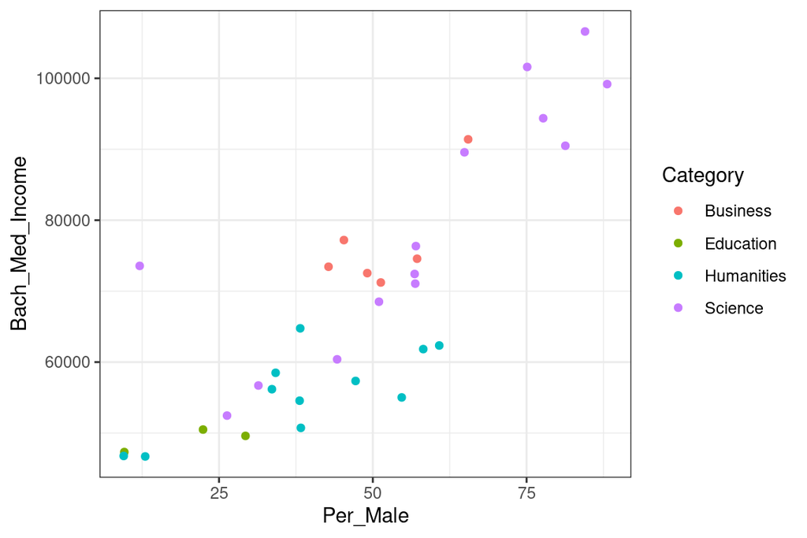

```r
ggplot(majors, aes(x = Per_Male, y = Bach_Med_Income, color = Category)) +
  geom_point()
```

```r
head(majors[, c(1, 2, 4, 22)])
```

```
##                     Major Category Per_Male Bach_Med_Income
## 1       Computer Science   Science     75.1          101600
## 2            Engineering   Science     81.3           90490
## 3      Civil Engineering   Science     77.7           94370
## 4 Electrical Engineering   Science     84.5          106600
## 5 Mechanical Engineering   Science     88.1           99180
## 6              Mathmatics  Science     57.0           76350
```

### Data

For this lab, one of the datasets we will be using is the `mpg` dataset included within the `ggplot2` package. This dataset contains a subset of fuel economy data that the EPA collected for various car models in 1999 and 2008. We begin with a quick visual inspection of the variables in our dataset:

```r
head(mpg)
```

```
##   manufacturer model displ year cyl      trans drv cty hwy fl   class
## 1         audi    a4   1.8 1999   4   auto(l5)   f  18  29  p compact
## 2         audi    a4   1.8 1999   4 manual(m5)   f  21  29  p compact
## 3         audi    a4   2.0 2008   4 manual(m6)   f  20  31  p compact
## 4         audi    a4   2.0 2008   4   auto(av)   f  21  30  p compact
## 5         audi    a4   2.8 1999   6   auto(l5)   f  16  26  p compact
## 6         audi    a4   2.8 1999   6 manual(m5)   f  18  26  p compact
```

A description of all of the variables can be read with `?mpg`.

### Aesthetics

The aesthetics of a `ggplot2` plot (which we simply call a “ggplot”) establish the most general properties relating our collected data to the visual representation we wish to create. Specifically, the aesthetics create a map *from the variables in the data* to visual properties of the graph. This will be an important point to keep in the back of our minds as our aesthetics becoming increasingly more detailed.

For example, suppose we wish to specify that we want the `cty` (city mpg) to be represented on the x-axis of our plot. The general syntax is as follows:

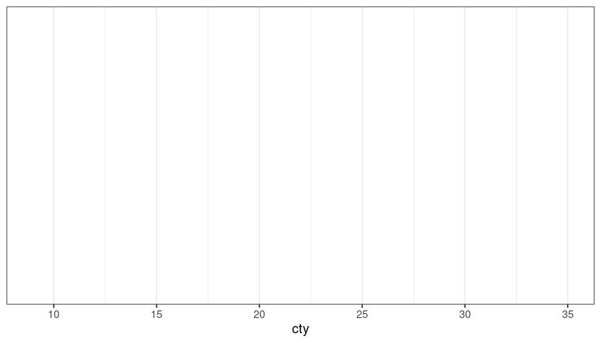

```r
ggplot(mpg, aes(x = cty))
```

To include a variable on the y-axis, we would also specify this in the aesthetic. Here, we create a blank plot that has city mileage on the x-axis and highway mileage on the y-axis

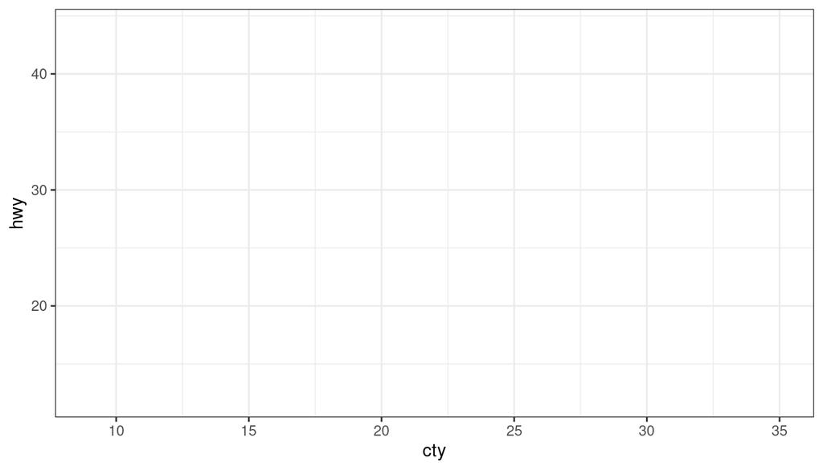

```r
ggplot(mpg, aes(x = cty, y = hwy))
```

Every ggplot will begin this way: we have the name of the function (`ggplot()`), the data that is being used (`mpg`), and a set of variables that we wish to include in the aesthetics (`aes(x = cty, y = hwy)`). Recall that the names of the variables in a dataset can be found in the Environment Panel. Of course, not every plot will require both axes – a histogram, for example, only needs an x-axis.

We will see additional interesting components that we can add to the aesthetics shortly.

### Layers

The actual visual components that we wish to include in the plot are given in *layers* which we add to the plot with `+`. The layers in ggplot are often referred to as “geoms” (for geometry) and are added following the `ggplot`. For example, here we add the “point” geom to create a scatterplot

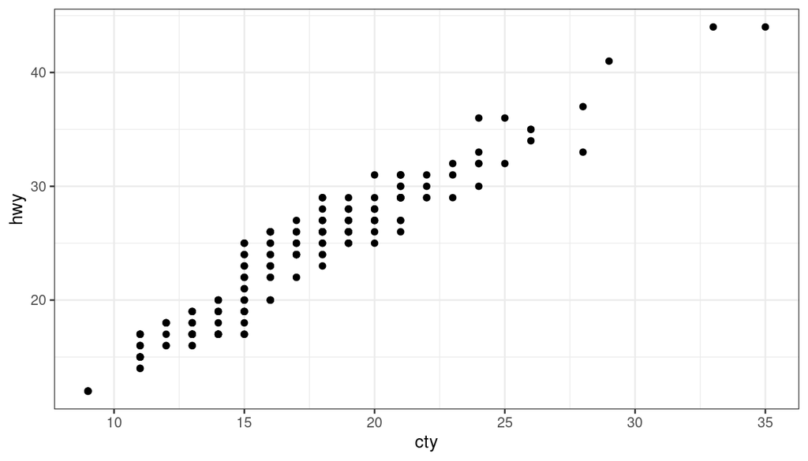

```r
ggplot(mpg, aes(x = cty, y = hwy)) +
  geom_point()
```

Note that this is the same plot that we had created above, except now we have added a layer of points.

Most (but not all) layers that we might add in ggplot begin with `geom_` to help indicate that they can be thought of as the actual, geometric elements (lines, points, etc.,) that you will see on the plot. In addition to `geom_point()`, there are a few others that are worth being aware of:

- `geom_point` - scatter plots
- `geom_jitter` – scatter plot with “jittered” coordinates
- `geom_bar` - bar graph for categorical data
- `geom_smooth` - smoother for data
- `geom_boxplot` - box plot
- `geom_histogram` - histograms
- `geom_violin` - violin plot

### Additional Aesthetics

While the x and y axes are the most common aesthetics, we can take advantage of the mapping between data and visual properties. Here, we consider the `majors` dataset as an example, plotting the relationship between percentage male in a field against the median income for a bachelor’s degree:

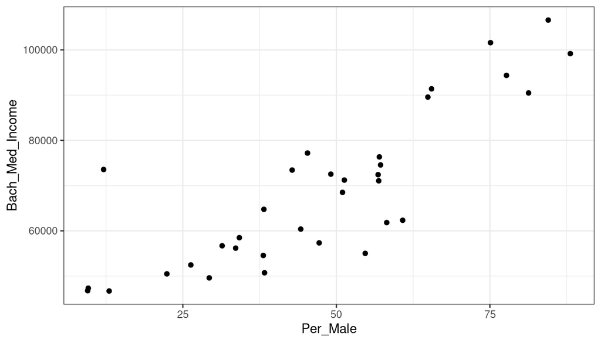

```r
ggplot(majors, aes(Per_Male, Bach_Med_Income)) +
  geom_point()
```

Consider the additional information we see when we include `color` in the aesthetics:

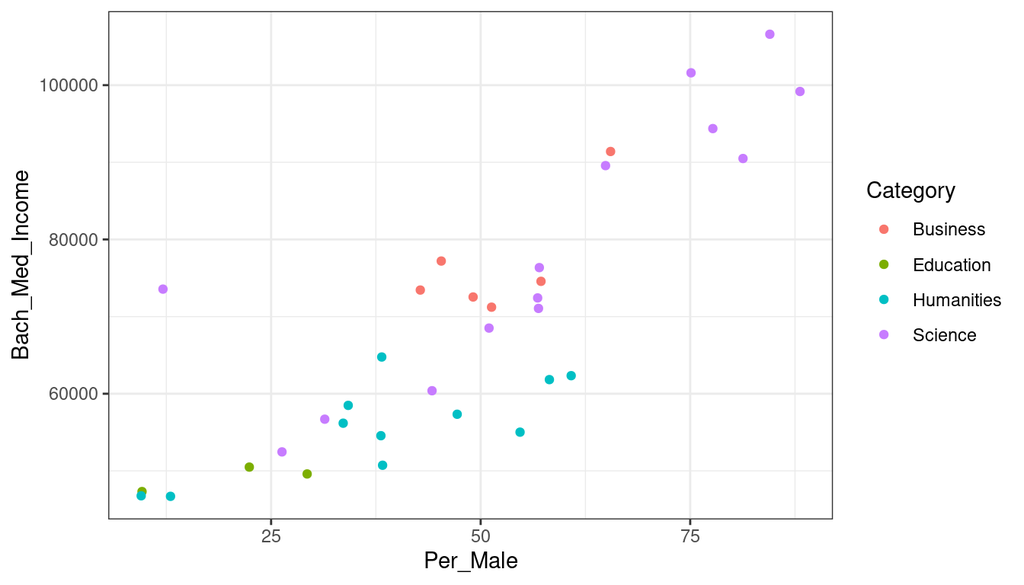

```r
## Adding color = Category
ggplot(majors, aes(Per_Male, Bach_Med_Income, color = Category)) +
  geom_point()
```

This is an example of a *multivariate* plot; it allows us to succinctly describe the relationship between 3 or more variables.

**Question 1:** Looking at the multivariate plot above, what additional information is gleaned by including `Category` as one of the variables?

This lab will be divided into three sections: creating univariate plots, bivariate plots, and then exploring multivariate plots. At the end of the lab is a (mostly) comprehensive collection of examples. These examples include different *arguments* that we can add to a ggplot to change, for example, how the bar charts are organized or to modify the number of bins in a histogram.

# Problem Sets

## Part 1 - Univariate Plots

**Question 2:** The `class` variable in the `mpg` dataset details the “type” of car for each observation (pickup, SUV). Create the appropriate graph to demonstrate this distribution of this variable and comment on which class appears to be the most frequent.

**Question 3:** The `cty` variable in the `mpg` dataset details the average fuel economy for the vehicle when driven in the city. Create the appropriate graph to represent this variable. Does this variable appear to be symmetric or skewed?

## Part 2 - Bivariate Plots

**Question 4:** Using the `mpg` dataset, we are interested in determining if either front wheel drive, rear wheel drive, or 4 wheel drive have better highway fuel economy. Create the appropriate plot to show the distribution of fuel economy for each of these types of vehicles. Which appears to have the best fuel economy?

**Question 5:** In the `majors` dataset, the variable `Per_Masters` describes the percentage of the workforce within a particular field whose highest degree is a master’s degree. Create a graph to assess whether or not there appears to be a relationship between the percentage of individuals who hold a master’s degree and the percent that is unemployed. What do you find?

**Question 6:** Using the `mpg` dataset, create a plot to find which vehicle `class` produces the largest number of vehicles with 6 cylinder (`cyl`) engines. Which produces the largest proportion of 6 cylinder engines?

## Part 3 - Multivariate Plots

**Question 7** First, using the `college` dataset, create a plot demonstrating the relationship between the region of the schools and their admission rates. Then, use either color/fill or faceting to add the `Private` variable to the plot. Now create the same plot again, this time adding color if you previously faceted or facet if you previously added color. Between these two plots, which appears the most useful in describing the relationship between these three variables?

**Question 8** Below is code that reads in `tips` data that are used in the Example section of this lab. First identify the four variables from the `tips` data that are used to make this plot and then write code to reproduce it. (This plot uses *faceting* which has examples at the end of the lab)

```r
tips <- read.csv("https://remiller1450.github.io/data/Tips.csv")
```

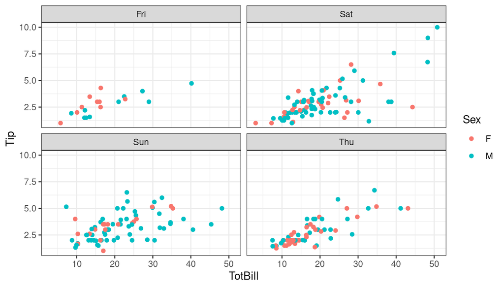

**Question 9** The code below will load a data set containing 970 Hollywood films released between 2007 and 2011, then reduce these data to only include variables that could be known prior to a film’s opening weekend. The data are then simplified further to only include the four largest studios (Warner Bros, Fox, Paramount, and Universal) in the three most common genres (action, comedy, drama). You will use the resulting data for this question.

```r
## Read in data
movies <- read.csv("https://remiller1450.github.io/data/HollywoodMovies.csv")

## Simplify data
movies <- subset(movies, LeadStudio %in% c("Warner Bros", "Fox", "Paramount", "Universal") &
                               Genre %in% c("Action", "Comedy", "Drama"),
                       select = c("Movie", "LeadStudio", "Story", "Genre","Budget",
                                  "TheatersOpenWeek","Year","OpeningWeekend"))
```

Your goal in this question is to create a graphic that effectively differentiates movies with high revenue on opening weekend from those with low revenue on opening weekend (the variable `OpeningWeekend` records this revenue in millions of US dollars).

Your plot should include *at least* three variables from the dataset, either by including them in the axes, through color or fill, or through faceting. Finally, using the graph you have created, write 2-3 sentences explaining what trends you found and what attributes seem to predict a film having low or high opening weekend revenue.

# Examples

These examples will be done with the `tips` dataset, loaded in below:

```r
## Read in the "Tips" data
tips <- read.csv("https://remiller1450.github.io/data/Tips.csv")
```

## Histograms

We can change the number of bins with `bins` argument. Feel free to play around with different numbers until you get what you want

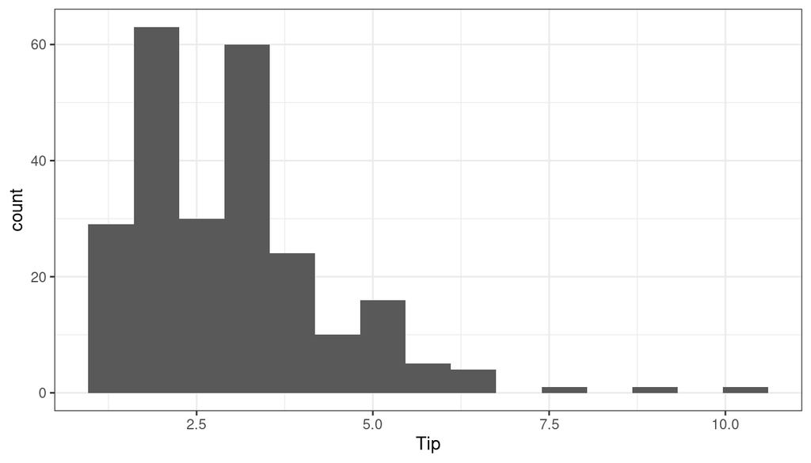

```r
ggplot(tips, aes(x = Tip)) + geom_histogram(bins = 15)
```

I think the default colors here are incredibly ugly, so I usually add lines and a slightly less offensive color to histograms in one variable

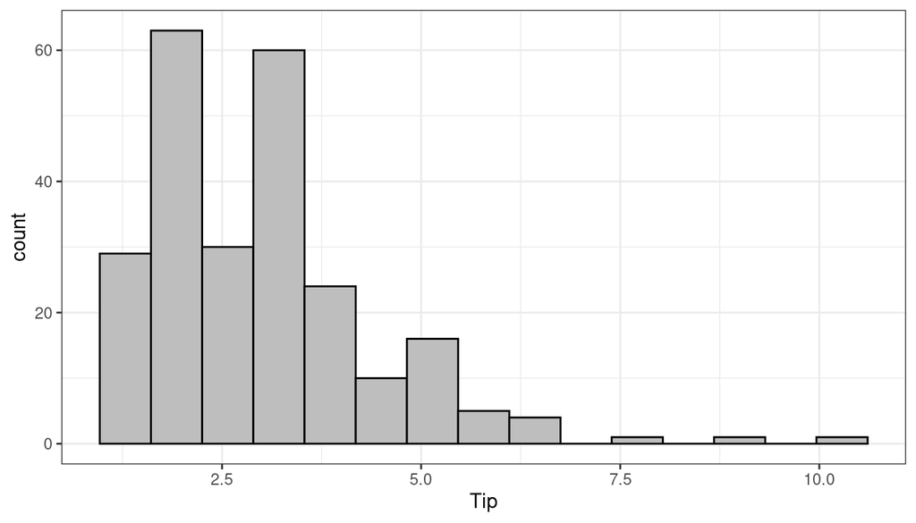

```r
ggplot(tips, aes(x = Tip)) + geom_histogram(bins = 15, color = 'black', fill = 'gray')
```

## Boxplots

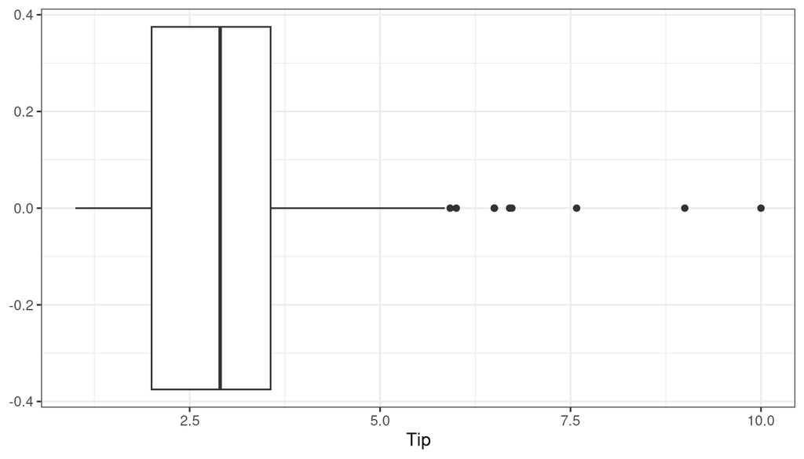

```r
ggplot(tips, aes(x = Tip)) + geom_boxplot()
```

We can add groups by passing an extra categorical argument to `aes()`

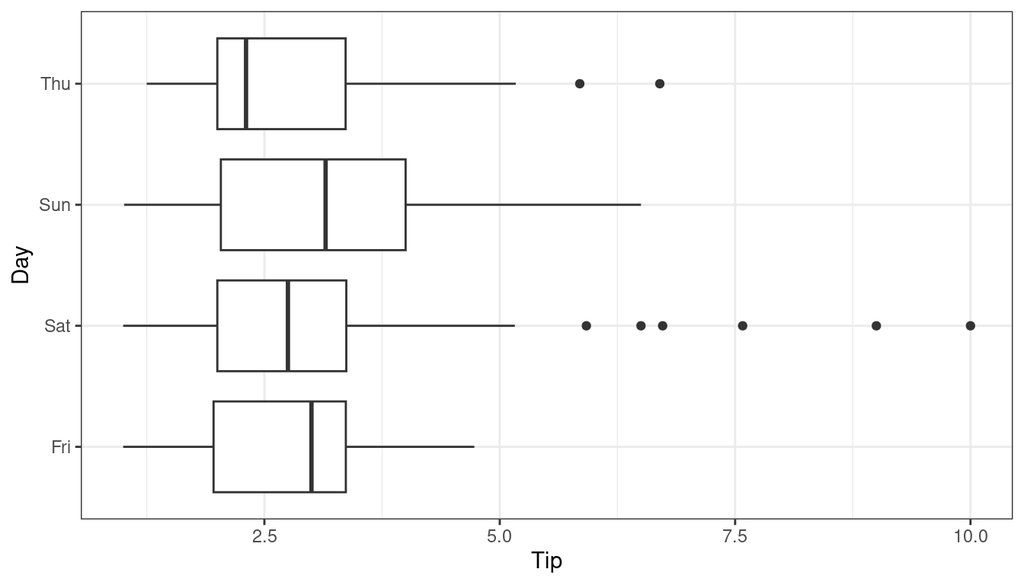

```r
ggplot(tips, aes(Tip, y = Day)) + geom_boxplot()
```

We can add more groups by including a color or fill aesthetic:

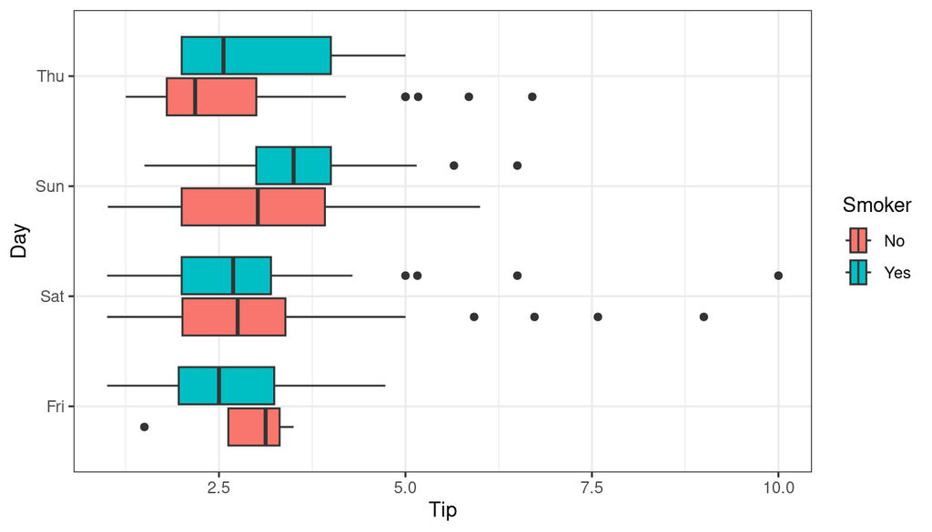

```r
ggplot(tips, aes(Tip, y = Day, fill = Smoker)) + geom_boxplot()
```

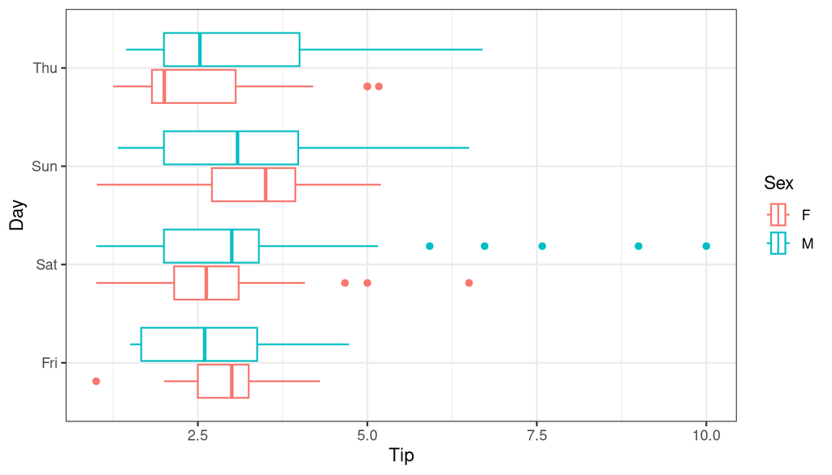

```r
ggplot(tips, aes(Tip, y = Day, color = Sex)) + geom_boxplot()
```

## Scatter plots

A basic scatter plot requires only two quantitative variables

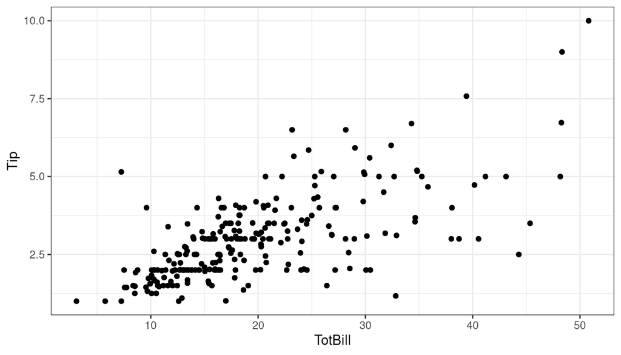

```r
ggplot(tips, aes(TotBill, Tip)) + geom_point()
```

We can add color to this plot to represent a third variable: note that categorical variables will create a collection of “discrete” colors, while adding a quantitative variable will give us color on a scale

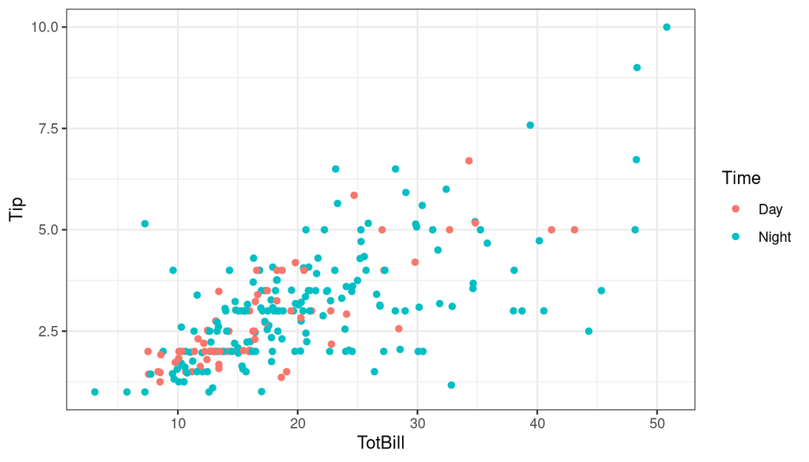

```r
# Categorical variable added
ggplot(tips, aes(TotBill, Tip, color = Time)) + geom_point()
```

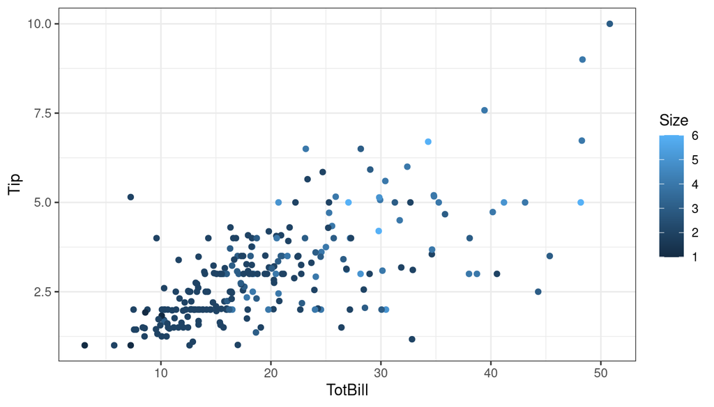

```r
# Quantitative variable added
ggplot(tips, aes(TotBill, Tip, color = Size)) + geom_point()
```

## Bar plots

The simplest box plot returns the distribution of a single variable

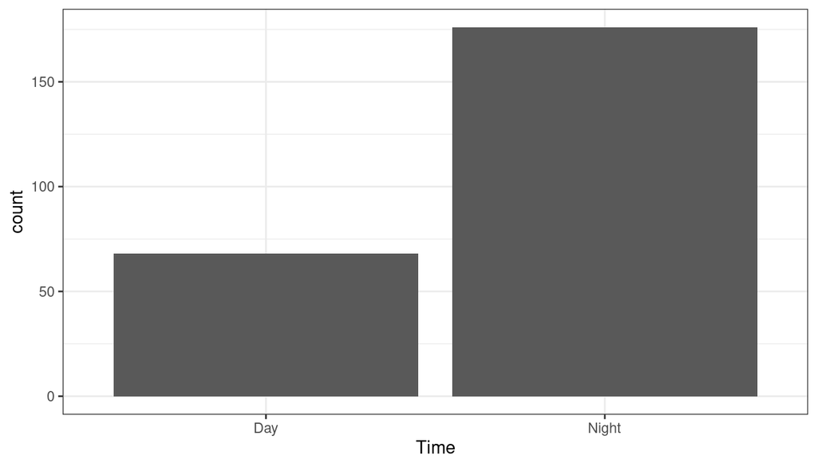

```r
ggplot(tips, aes(Time)) + geom_bar()
```

#### Stacked

When adding additional categorical variables, the default behavior is to give a stacked bar chart

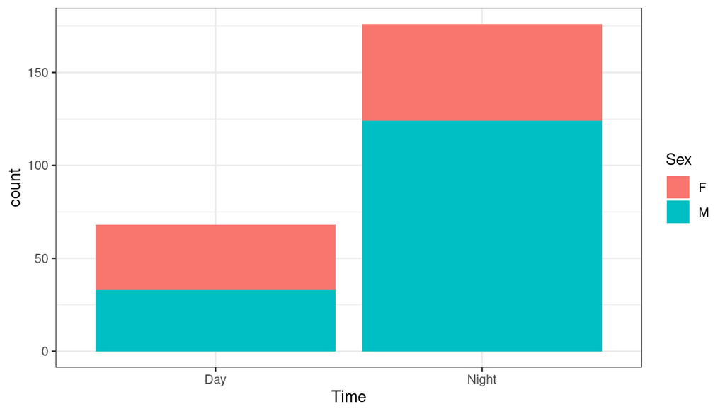

```r
ggplot(tips, aes(Time, fill = Sex)) + geom_bar()
```

Note that for bar charts our second aesthetic will almost always be `fill =`. This tells ggplot to “fill in” with the color of the group. Try doing `color = Sex` to compare

#### Dodge

We can change to a dodged bar chart by passing an argument to `geom_bar()`

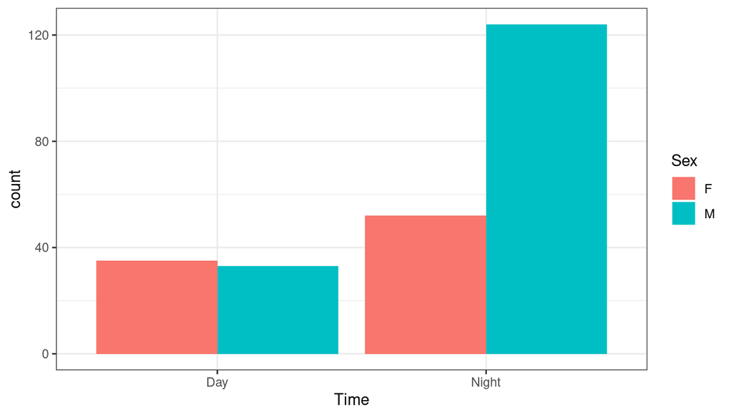

```r
ggplot(tips, aes(Time, fill = Sex)) + geom_bar(position = "dodge")
```

If there is a case in which one group has zero observations from another group, the default behavior for dodge looks weird. Here’s an example from the `mpg` dataset:

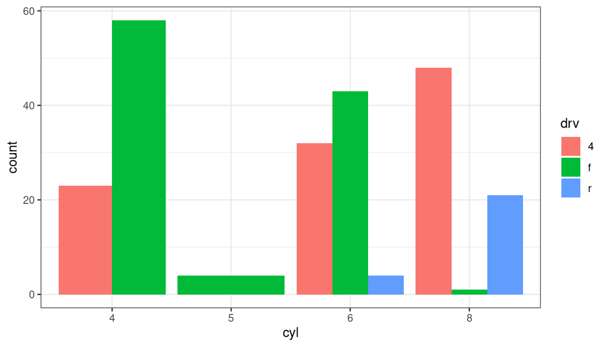

```r
ggplot(mpg, aes(cyl, fill = drv)) + geom_bar(position = "dodge")
```

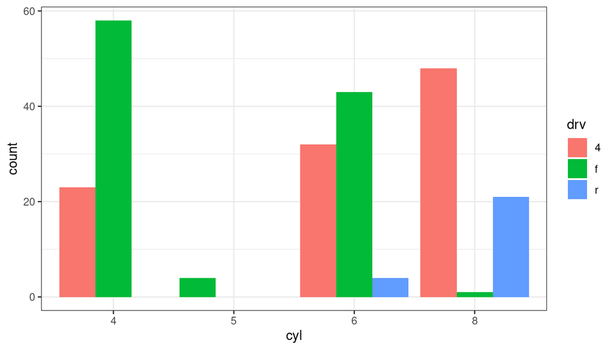

```r
ggplot(mpg, aes(cyl, fill = drv)) + geom_bar(position = position_dodge(preserve = "single"))
```

#### Filled charts (conditional)

Finally, we can get the filled/conditional charts by using `position = "fill"`

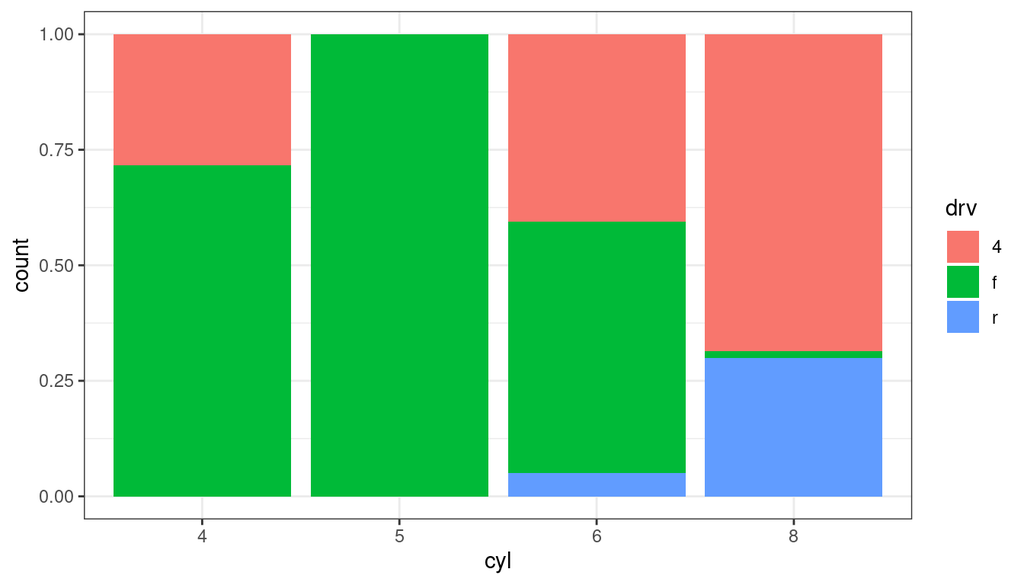

```r
ggplot(mpg, aes(cyl, fill = drv)) + geom_bar(position = "fill")
```

## Faceting

“Facetting” is a process whereby we split our plots up by a group or categorical variable, allowing us to see two (or more) side-by-side plots. This can be a handy way to view the relationship between two variables separately, conditioned on a third

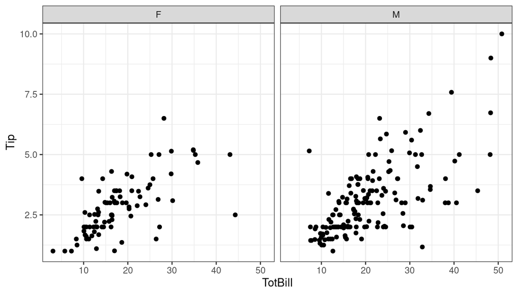

```r
ggplot(tips, aes(TotBill, Tip)) +
  geom_point() +
  facet_wrap(~Sex)
```

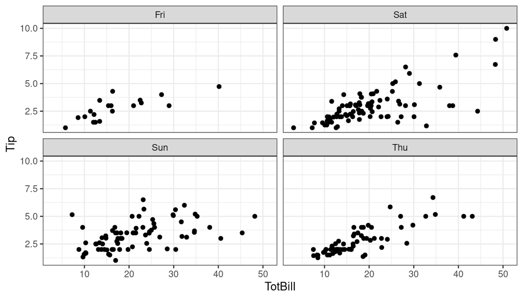

```r
ggplot(tips, aes(TotBill, Tip)) +
  geom_point() +
  facet_wrap(~Day)
```

The syntax is `facet_wrap(~var_name)` and can be added with `+` at the end of the plot

## Extra Details

Here are some extra examples for things you may be intereseted in modifying in your plot

## Labels and title

We can add labels and a title with the `labs()` function (short for labels). The arguments to change labels are shown below

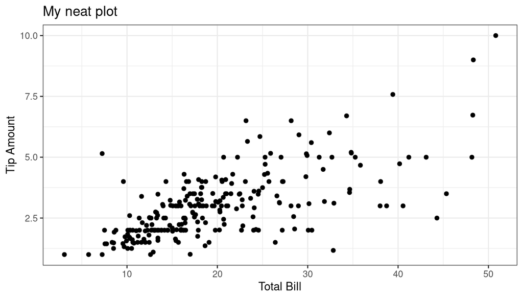

```r
ggplot(tips, aes(TotBill, Tip)) +
  geom_point() +
  labs(x = "Total Bill", y = "Tip Amount", title = "My neat plot")
```

#### Colors

This is (mostly) just for fun. If we use either a color or fill aesthetic in our plots, we can change the colors

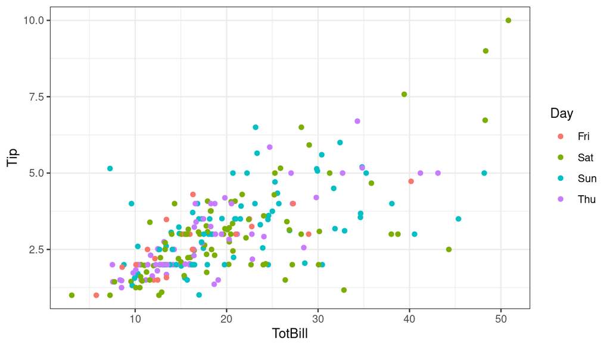

```r
# Original
ggplot(tips, aes(TotBill, Tip, color = Day)) +
  geom_point()
```

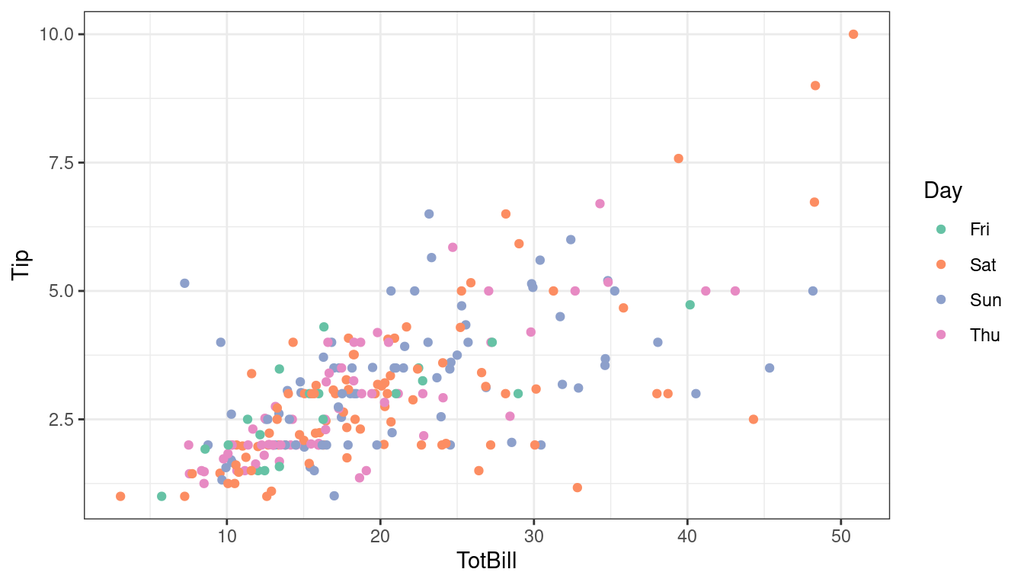

```r
# Using scale_color_brewer
ggplot(tips, aes(TotBill, Tip, color = Day)) +
  geom_point() +
  scale_color_brewer(palette = "Set2")
```

The syntax is nearly identical for fill using `scale_fill_brewer()`

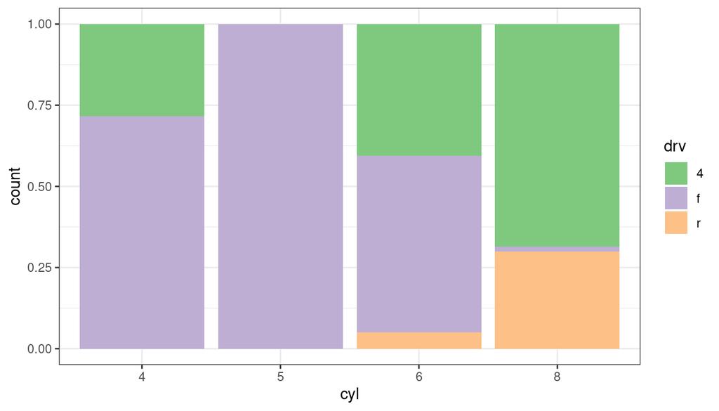

```r
ggplot(mpg, aes(cyl, fill = drv)) +
  geom_bar(position = "fill") +
  scale_fill_brewer(palette = "Accent")
```

A list of additional palettes can be found with `?scale_fill_brewer()` or `?scale_fill_color()`